# Visualizing Airbnb Listings in San Francisco

**Task:** Exploratory Analysis Using ggplot2

**Dataset:** Airbnb listings in San Francisco, the dtaset contains 16 variables and 6998 observations. The data can be obtained from [http://data.insideairbnb.com/united-states/ca/san-francisco/2020-10-05/visualisations/listings.csv]

load required libraries

```r
library(tidyverse)
```

**Data Preparation and Preprocessing**

Import data and check on its structure

```r
listings <- read.csv("listings.csv")
str(listings)
```

```
## 'data.frame':    6998 obs. of  16 variables:
##  $ id                            : int  958 5858 7918 8014 8142 8339 8739 10251 10578 10820 ...
##  $ name                          : chr  "Bright, Modern Garden Unit - 1BR/1BTH" "Creative Sanctuary" "A Friendly Room - UCSF/USF - San Francisco" "Newly Remodeled room in big house WIFI market" ...
##  $ host_id                       : int  1169 8904 21994 22402 21994 24215 7149 35199 37049 38836 ...
##  $ host_name                     : chr  "Holly" "Philip And Tania" "Aaron" "Jia" ...
##  $ neighbourhood_group           : logi  NA NA NA NA NA NA ...
##  $ neighbourhood                 : chr  "Western Addition" "Bernal Heights" "Haight Ashbury" "Outer Mission" ...
##  $ latitude                      : num  37.8 37.7 37.8 37.7 37.8 ...
##  $ longitude                     : num  -122 -122 -122 -122 -122 ...
##  $ room_type                     : chr  "Entire home/apt" "Entire home/apt" "Private room" "Private room" ...
##  $ price                         : int  131 235 56 45 56 743 169 200 120 170 ...
##  $ minimum_nights                : int  2 30 32 5 32 5 1 30 30 30 ...
##  $ number_of_reviews             : int  262 111 19 85 8 28 736 337 18 37 ...
##  $ last_review                   : chr  "2020-09-16" "2017-08-06" "2020-03-06" "2018-10-01" ...
##  $ reviews_per_month             : num  1.92 0.8 0.14 0.85 0.11 0.21 5.41 2.5 0.17 0.28 ...
##  $ calculated_host_listings_count: int  1 1 9 2 9 2 2 1 1 38 ...
##  $ availability_365              : int  206 365 365 45 365 0 179 365 364 73 ...
```

Change data types

```r
listings$last_review <- as.Date(listings$last_review) #change data type of last_review to Date
listings$room_type <- factor(listings$room_type) #room_type data type from character to factor
listings$neighbourhood <- factor(listings$neighbourhood) #neighbourhood data type from character to factor
listings$host_id <- factor(listings$host_id) #host_id from numeric to factor
```

Drop redundant columns and get the summary statistics

```r
listings <- listings[-c(1,4)] #drop id and host_name columns, id is insignificant and host_name for ethical reasons
summary(listings) # get the summary of the data
```

```
##      name                host_id     neighbourhood_group
##  Length:6998        107434423: 182   Mode:logical
##  Class :character   4430421  : 146   NA's:6998
##  Mode  :character   48005494 : 102
##                     262211596:  79
##                     70722023 :  55
##                     17042045 :  51
##                     (Other)  :6383
##                neighbourhood     latitude       longitude
##  Downtown/Civic Center: 711   Min.   :37.71   Min.   :-122.5
##  Mission              : 581   1st Qu.:37.75   1st Qu.:-122.4
##  South of Market      : 522   Median :37.77   Median :-122.4
##  Western Addition     : 489   Mean   :37.77   Mean   :-122.4
##  Castro/Upper Market  : 380   3rd Qu.:37.79   3rd Qu.:-122.4
##  Bernal Heights       : 327   Max.   :37.81   Max.   :-122.4
##  (Other)              :3988
##            room_type        price         minimum_nights      number_of_reviews
##  Entire home/apt:4244   Min.   :   10.0   Min.   :        1   Min.   :  0.00
##  Hotel room     :  95   1st Qu.:   89.0   1st Qu.:        2   1st Qu.:  1.00
##  Private room   :2479   Median :  140.0   Median :        7   Median :  9.00
##  Shared room    : 180   Mean   :  260.6   Mean   :    14308   Mean   : 45.23
##                         3rd Qu.:  229.0   3rd Qu.:       30   3rd Qu.: 50.00
##                         Max.   :25000.0   Max.   :100000000   Max.   :821.00
##
##   last_review         reviews_per_month calculated_host_listings_count
##  Min.   :2011-05-23   Min.   : 0.010    Min.   :  1.00
##  1st Qu.:2019-09-30   1st Qu.: 0.190    1st Qu.:  1.00
##  Median :2020-02-28   Median : 0.650    Median :  2.00
##  Mean   :2019-11-26   Mean   : 1.328    Mean   : 16.01
##  3rd Qu.:2020-08-01   3rd Qu.: 1.860    3rd Qu.:  9.00
##  Max.   :2020-10-06   Max.   :20.430    Max.   :182.00
##  NA's   :1557         NA's   :1557
##  availability_365
##  Min.   :  0.0
##  1st Qu.:  0.0
##  Median :113.0
##  Mean   :153.4
##  3rd Qu.:305.0
##  Max.   :365.0
##
```

Handling missing values,

```r
listings$neighbourhood_group <- NULL # drop neighbourhood_group column because it has all NA"s
listings$last_review <- NULL #drop last_review column, there are lots of NA's because if there were no reviews for the listings, the date doesn't exist
listings$reviews_per_month[is.na (listings$reviews_per_month)] <- 0 #replace the NA's in reviews_per_month with zero since there were no reviews for that particular day
```

**Exploratory Data Analysis:** VIsualization using ggplot2

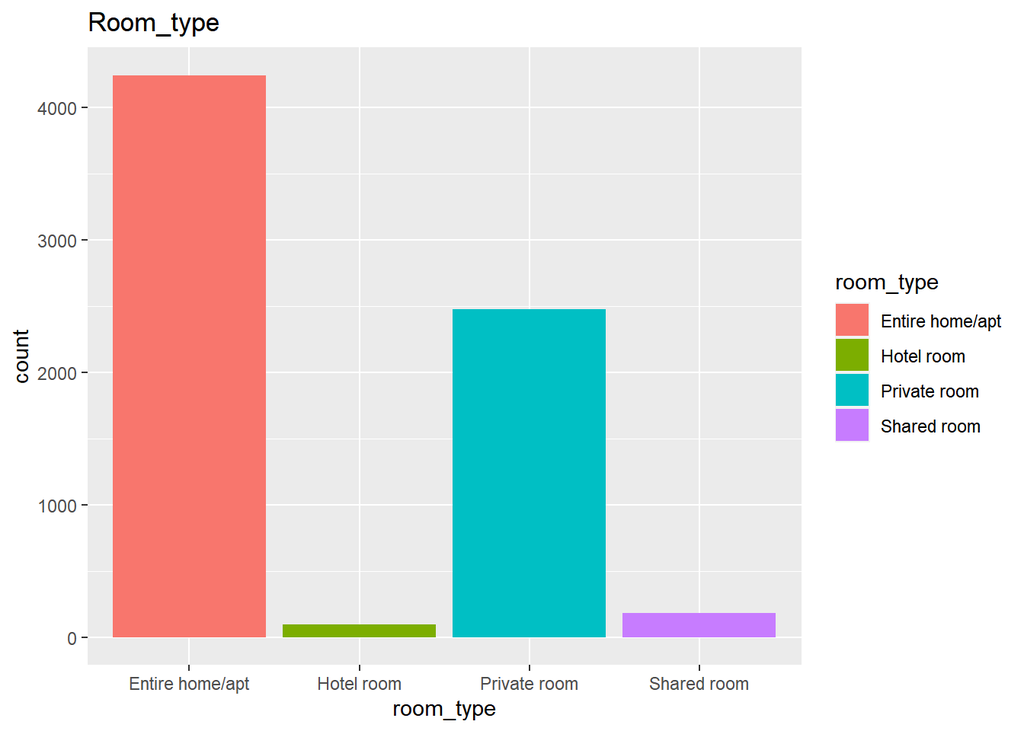

```r
#distribution of room_type
ggplot(listings, aes(x=room_type, fill=room_type)) + geom_bar() + labs(title = "Room_type")
```

Entire home/apartment is the most preferred by tourists followed by Private room. the least preferred is the Hotel room

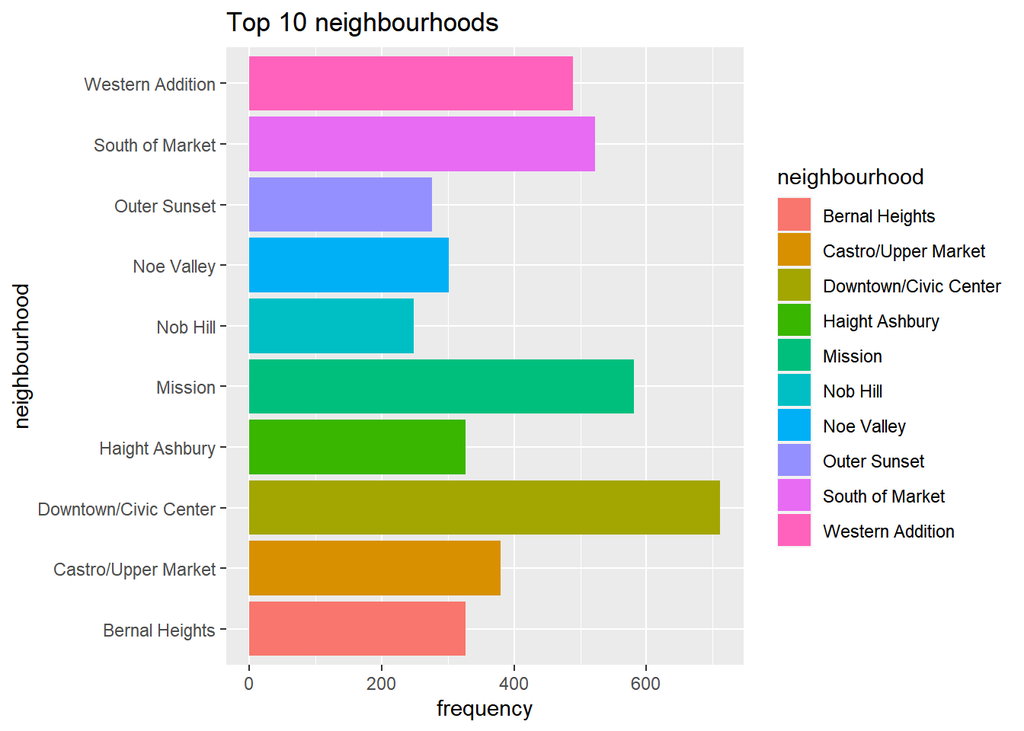

```r
#top 10 frequent neighbourhoods
listings %>% count(neighbourhood) %>% arrange(desc(n))%>% head(10) %>% ggplot(aes(x=neighbourhood, y=n, fill=neighbourhood)) +geom_bar(stat = "identity",position = "dodge") + coord_flip() + ylab("frequency") + labs(title = "Top 10 neighbourhoods")
```

From the bar chart, it can be deduced that, Donwntown/Civic Centre is the most preferred neighbourhood by tourists

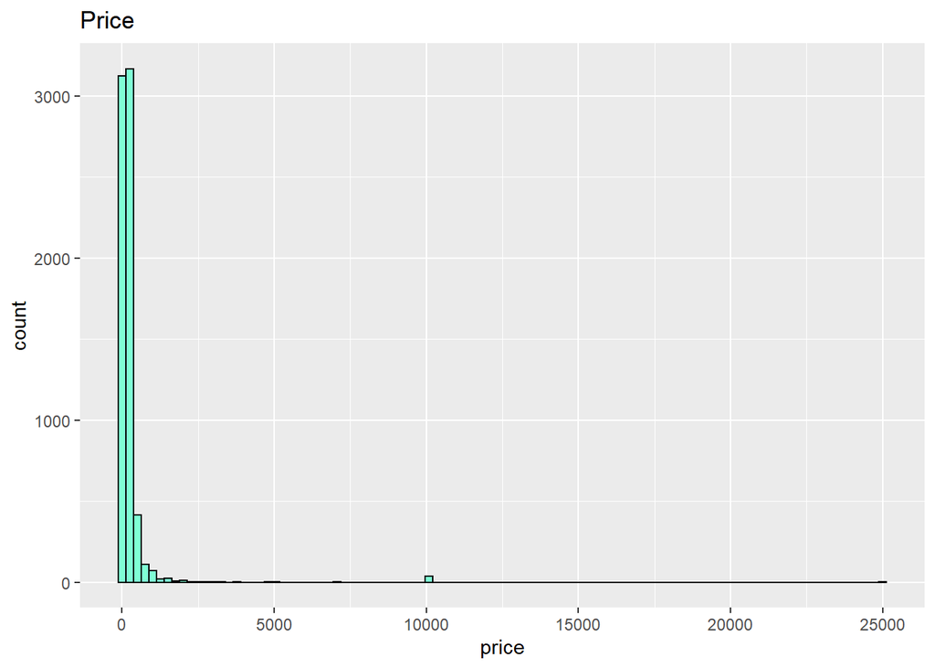

```r
#variation in Price
ggplot(listings, aes(x=price)) + geom_histogram(fill="aquamarine", bins = 100, color= "black") + labs(title = "Price") #the histogram is not that good
```

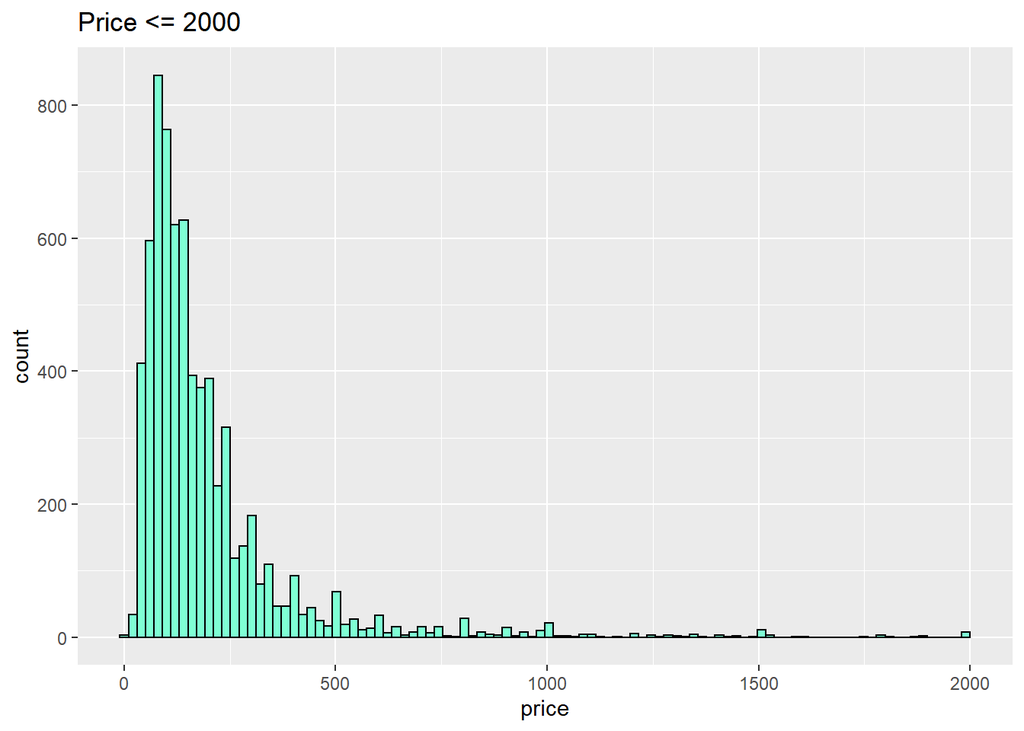

```r
df=data.frame(price=listings["price"][listings["price"]<=2000])
ggplot(df, aes(x= price)) + geom_histogram(fill="aquamarine", bins = 100, color="black") + labs(title = "Price <= 2000") #plot price <= 2000 for some clarity
```

THe first plot is not clear because of outliers the second plot is a bit clear where I considered the price of <=2000

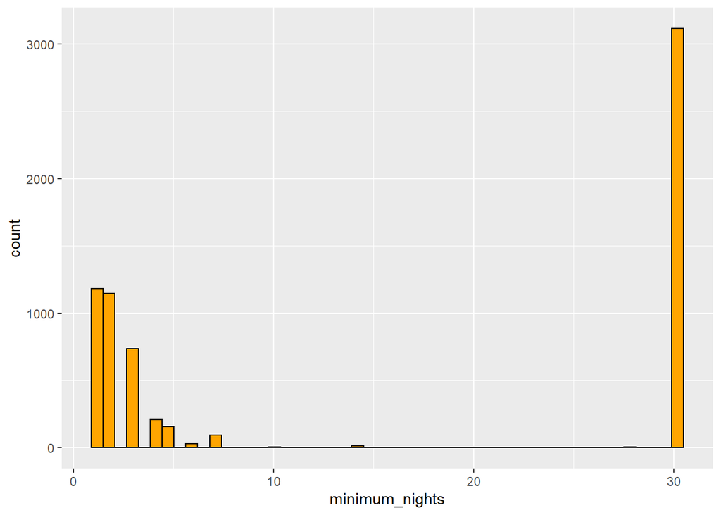

```r
df2= data.frame(minimum_nights=listings["minimum_nights"][listings["minimum_nights"]<=30])
ggplot(df2, aes(x=minimum_nights)) + geom_histogram(bins=50, fill="orange", color= "black")
```

minimum night of 30 has the highest listing

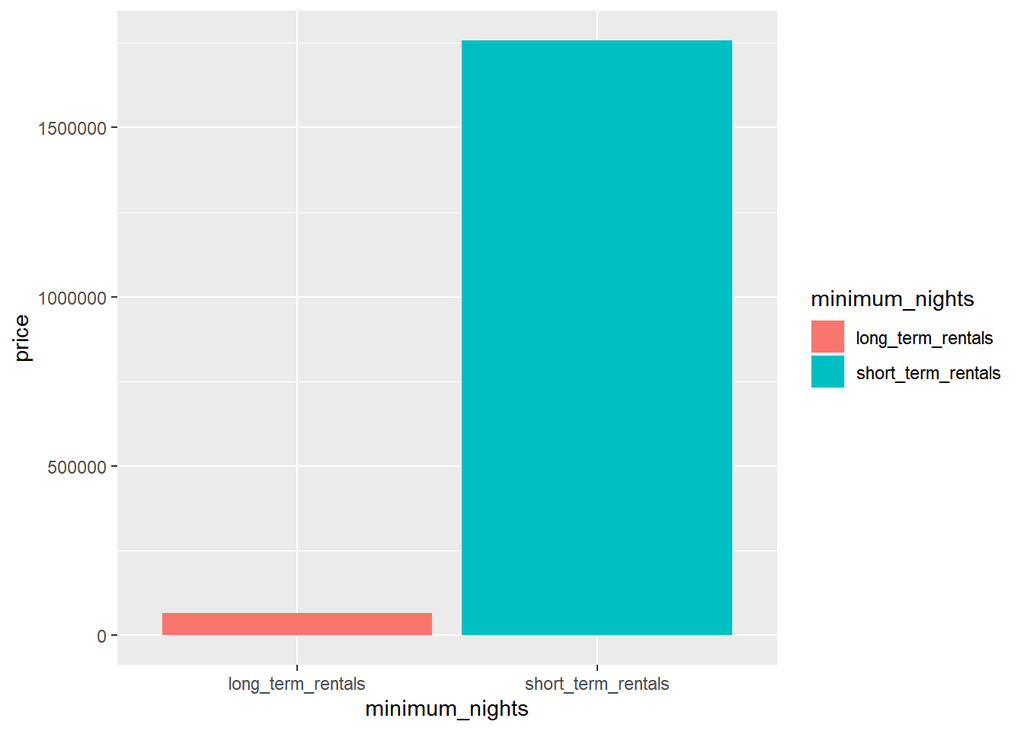

```r
listings %>% mutate(minimum_nights = ifelse(minimum_nights<=30, "short_term_rentals", "long_term_rentals")) %>% ggplot(aes(x=minimum_nights, y=price, fill= minimum_nights)) + geom_bar(stat = "identity")
```

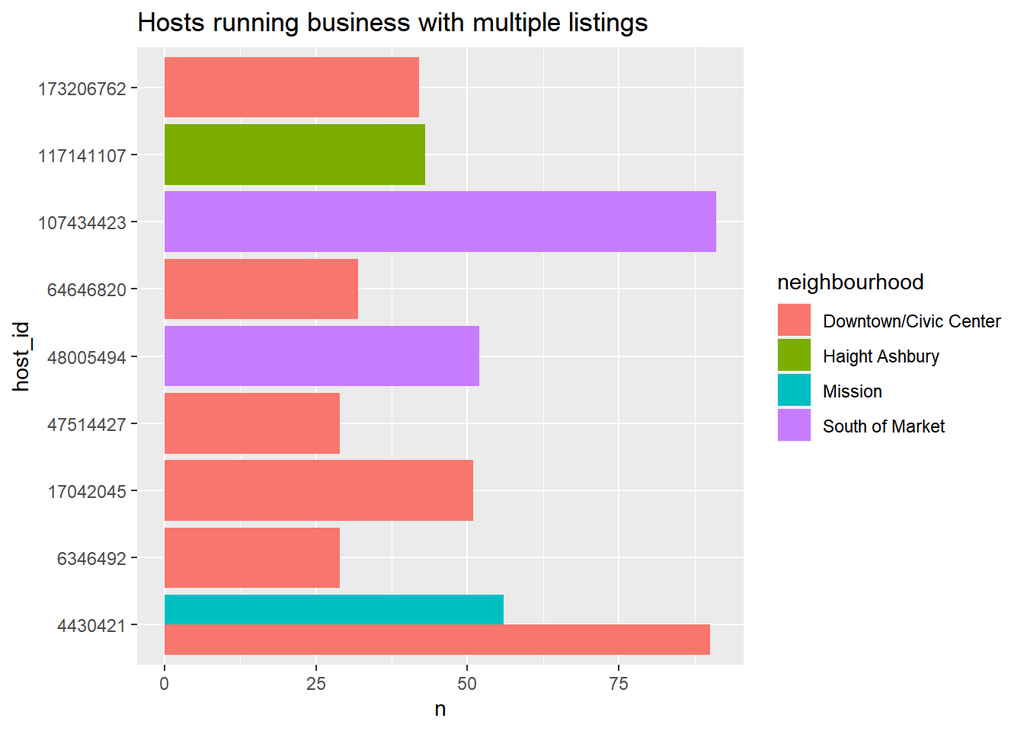

```r
#hosts running business with multiple listings
listings %>% group_by(neighbourhood) %>% count(host_id) %>% arrange(desc(n))%>% head(10) %>% ggplot(aes(x=host_id, y=n, fill=neighbourhood)) +geom_bar(stat = "identity", position="dodge") + coord_flip() + labs(title="Hosts running business with multiple listings")
```

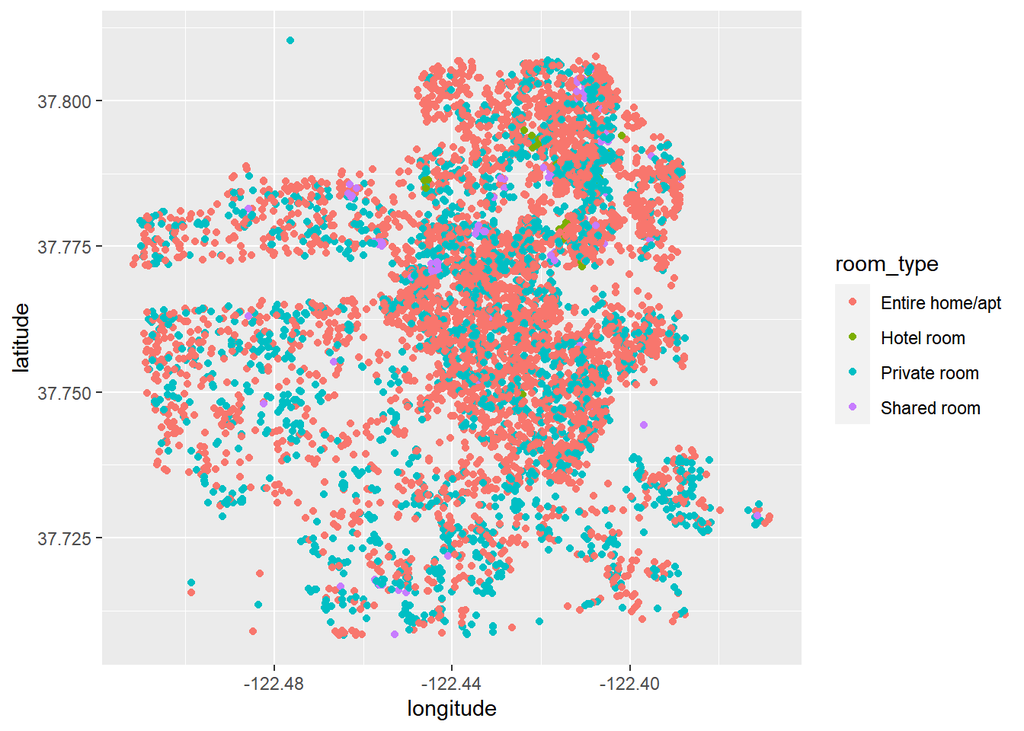

```r
#distibution of room_type across the region
ggplot(listings,aes(x=longitude, y= latitude, color=room_type)) + geom_point()
```